# Final Project

Herbert Gutierrez, Varun Parameswaran, Ryan Wechter

December 7, 2015

# Health Care and Causes of Death by State

#### Final Project for Dr. Cannata’s Data Visualization Class

### Introduction

Today we are here to present our data from two different data sets focused on Health care expenditure by state and Causes of death by state. In order to present our data we felt it was appropriate to use all the resources available to use including Rstudio, Shiny, Tableau and SQL.

### Loading our data from the Oracle Database

First, we loaded in our data from the Oracle database as follows. We added two extra datasets to our primary two datasets we’d been using throughout this class.

```r
source("../01 Data/COD_ETL.R", echo = TRUE)
```

```
##
## > require("ggplot2")
##
## > require("gplots")
##
## > require("grid")
##
## > require("RCurl")
##
## > require("reshape2")
##
## > require("tableplot")
##
## > require("tidyr")
##
## > require("dplyr")
##
## > require("jsonlite")
##
## > require("lubridate")
##
## > COD <- data.frame(fromJSON(getURL(URLencode("skipper.cs.utexas.edu:5001/rest/native/?query=\"select * from COD\""),
## +     httpheader = c(DB = "jdbc ..." ... [TRUNCATED]
##
## > summary(COD)
##                                              X113_CAUSE_NAME
##  Accidents (unintentional injuries) (V01-X59,Y85-Y86): 780
##  All Causes                                          : 780
##  Alzheimers disease (G30)                            : 780
##  Chronic liver disease and cirrhosis (K70,K73-K74)   : 780
##  Chronic lower respiratory diseases (J40-J47)        : 780
##  Diabetes mellitus (E10-E14)                         : 780
##  (Other)                                             :6802
##                                CAUSE_NAME             STATE
##  All Causes                         : 780   Wisconsin    :  239
##  Alzheimers disease                 : 780   United States:  237
##  Cancer                             : 780   Utah         :  237
##  Chronic liver disease and cirrhosis: 780   Washington   :  237
##  CLRD                               : 780   West Virginia:  237
##  Diabetes                           : 780   Tennessee    :  235
```

[output cut: 10 more lines]

```
## > head(COD)
##                                X113_CAUSE_NAME CAUSE_NAME         STATE
## 1 Assault (homicide) (*U01-*U02,X85-Y09,Y87.1)   Homicide United States
## 2 Assault (homicide) (*U01-*U02,X85-Y09,Y87.1)   Homicide          Utah
## 3           Cerebrovascular diseases (I60-I69)     Stroke     Tennessee
## 4           Cerebrovascular diseases (I60-I69)     Stroke         Texas
## 5           Cerebrovascular diseases (I60-I69)     Stroke United States
## 6           Cerebrovascular diseases (I60-I69)     Stroke          Utah
##   YEAR DEATHS  AADR
## 1 1999  16889  5.99
## 2 1999     51  2.29
## 3 1999   4103 76.32
## 4 1999  10414 65.89
## 5 1999 167366 61.61
## 6 1999    869 60.18
```

Our second dataset (NHCE) describes national healthcare expenditures by item, region, and state from 1980 - 2009. An important additional statistic here is average annual percent growth. Below is a head and summary.

```r
source("../01 Data/NHCE_ETL.R", echo = TRUE)
```

```
##
## > require("ggplot2")
##
## > require("gplots")
##
## > require("grid")
##
## > require("RCurl")
##
## > require("reshape2")
##
## > require("tableplot")
##
## > require("tidyr")
##
## > require("dplyr")
##
## > require("jsonlite")
##
## > require("lubridate")
##
## > NHCE <- data.frame(fromJSON(getURL(URLencode("skipper.cs.utexas.edu:5001/rest/native/?query=\"select * from NHCE\""),
## +     httpheader = c(DB = "jd ..." ... [TRUNCATED]
##
## > summary(NHCE)
##       CODE
##  Min.   : 1
##  1st Qu.: 3
##  Median : 6
##  Mean   : 6
##  3rd Qu.: 9
##  Max.   :11
##
##                                                                  ITEM
##  Dental Services (Millions of Dollars)                             : 60
##  Durable Medical Products (Millions of Dollars)                    : 60
##  Home Health Care (Millions of Dollars)                            : 60
##  Hospital Care (Millions of Dollars)                               : 60
##  Nursing Home Care (Millions of Dollars)                           : 60
##  Other Health, Residential, and Personal Care (Millions of Dollars): 60
```

[output cut: 133 more lines]

```
## 6   4942.532   5386.165   5823.735   6402.715   7113.810   7979.961
##        Y2002      Y2003      Y2004      Y2005      Y2006      Y2007
## 1   2016.511   2149.879   2279.970   2482.574   2703.165   2897.564
## 2 206928.500 226194.391 242641.844 261159.594 277806.500 297905.875
## 3   3637.501   3925.309   4209.651   4728.505   4996.153   5349.348
## 4 145281.391 159398.750 170755.844 183427.875 194564.453 208444.109
## 5   5565.963   6035.264   6441.714   6990.909   7308.066   8011.608
## 6   9139.332  10123.869  11252.733  12218.745  13200.090  14220.917
##        Y2008      Y2009 AVERAGE_ANNUAL_PERCENT_GROWTH
## 1   3088.065   3258.244                           8.2
## 2 316639.000 332085.812                           8.0
## 3   5811.577   6185.036                           9.2
## 4 221093.797 231025.766                           7.7
## 5   8524.489   8899.369                           8.0
## 6  14836.609  15283.862                          10.5
```

Our third dataset (state_pop) describes state population by state, along with average percent growth, from 2000 - 2009. Below is a head and summary.

```r
source("../01 Data/StatePop_ETL.R", echo = TRUE)
```

```
##
## > require("ggplot2")
##
## > require("gplots")
##
## > require("grid")
##
## > require("RCurl")
##
## > require("reshape2")
##
## > require("tableplot")
##
## > require("tidyr")
##
## > require("dplyr")
##
## > require("jsonlite")
##
## > require("lubridate")
##
## > state_pop <- data.frame(fromJSON(getURL(URLencode("skipper.cs.utexas.edu:5001/rest/native/?query=\"select * from state_pop\""),
## +     httpheader =  .... [TRUNCATED]
##
## > summary(state_pop)
##         STATE          ZERO          ONE           TWO          THREE
##  Alabama   : 1   1050736 : 1   10006093: 1   10038767: 1   10066351: 1
##  Alaska    : 1   11363844: 1   1058051 : 1   1066034 : 1   1071504 : 1
##  Arizona   : 1   1211566 : 1   11396874: 1   11420981: 1   11445180: 1
##  Arkansas  : 1   12285504: 1   1218305 : 1   1228069 : 1   12357524: 1
##  California: 1   1240446 : 1   12299533: 1   12326302: 1   1239298 : 1
##  Colorado  : 1   12437645: 1   12507833: 1   12558229: 1   12597981: 1
##  (Other)   :47   (Other) :47   (Other) :47   (Other) :47   (Other) :47
##        FOUR          FIVE          SIX          SEVEN         EIGHT
##  10089305: 1   10090554: 1   10082438: 1   10050847: 1   10002486: 1
##  1071414 : 1   1064989 : 1   1060196 : 1   1055009 : 1   1053502 : 1
##  11464593: 1   11475262: 1   11492495: 1   11520815: 1   11528072: 1
##  12388368: 1   12418161: 1   12471142: 1   12522531: 1   12566368: 1
##  1252782 : 1   1266117 : 1   12718011: 1   1276832 : 1   12842954: 1
##  12645295: 1   12674452: 1   1275599 : 1   12779417: 1   1287481 : 1
```

[output cut: 10 more lines]

```
## > head(state_pop)
##        STATE     ZERO      ONE      TWO    THREE     FOUR     FIVE
## 1    Alabama  4451849  4464034  4472420  4490591  4512190  4545049
## 2     Alaska   627499   633316   642691   650884   661569   669488
## 3    Arizona  5166697  5304417  5452108  5591206  5759425  5974834
## 4   Arkansas  2678288  2691068  2704732  2722291  2746161  2776221
## 5 California 33994571 34485623 34876194 35251107 35558419 35795255
## 6   Colorado  4328070  4433068  4504265  4548775  4599681  4660780
##        SIX    SEVEN    EIGHT     NINE             PERCENT
## 1  4597688  4637904  4677464  4708708  0.0153374839574099
## 2   677325   682297   688125   698473  0.0022751078940928
## 3  6192100  6362241  6499377  6595778  0.0214841607958078
## 4  2815097  2842194  2867764  2889450 0.00941168889403343
## 5 35979208 36226122 36580371 36961664   0.120393730700016
## 6  4753044  4842259  4935213  5024748   0.016366908326745
```

Our fourth dataset (Inflation) gives the inflation rate from 1980 - 2009. Below is a head and summary.

```r
source("../01 Data/Inflation_ETL.R", echo = TRUE)
```

```
##
## > require("ggplot2")
##
## > require("gplots")
##
## > require("grid")
##
## > require("RCurl")
##
## > require("reshape2")
##
## > require("tableplot")
##
## > require("tidyr")
##
## > require("dplyr")
##
## > require("jsonlite")
##
## > require("lubridate")
##
## > INFLATION <- data.frame(fromJSON(getURL(URLencode("skipper.cs.utexas.edu:5001/rest/native/?query=\"select * from INFLATION\""),
## +     httpheader =  .... [TRUNCATED]
##
## > summary(INFLATION)
##  INFLATION_DATE INFLATION_RATE
##  Min.   :1980   Min.   :-0.02223
##  1st Qu.:1987   1st Qu.: 2.52590
##  Median :1994   Median : 3.15959
##  Mean   :1994   Mean   : 3.54821
##  3rd Qu.:2002   3rd Qu.: 3.98897
##  Max.   :2009   Max.   :12.35371
##
## > head(INFLATION)
##   INFLATION_DATE INFLATION_RATE
## 1           1980       12.35371
## 2           1981        8.91204
## 3           1982        3.82572
## 4           1983        3.78710
## 5           1984        4.04339
## 6           1985        3.79147
```

We created each of our visualizations in Tableau, then R workflows, ending finally SQL and Shiny.

## Visualization #1: Texas Leading Causes of Death 1999 - 2013

To begin we wanted to see how the distribution of deaths in the United States were represented based on different causes of death. Interestingly enough, the data showed that across America the leading causes were Cancer and Cardivascular causes. To narrow it down we focused only on Texas’ causes of death from 1999 - 2013 and the data was very similar to the national causes of death. As the data shows the two leading causes of deaths in Texas are both highly correlated with lifestyle choices such as diet, sleep, exercise and others. However, the other remaining causes of deaths are more focused on genetics rather than lifestyle choice. Therefore, in order to reduce the number of deaths in Texas (and in the US) it would be important to educate the public on healthier lifestyle choices.

#### Rstudio

```
##
## > COD %>% select(CAUSE_NAME, STATE, DEATHS, AADR, YEAR) %>%
## +     filter(STATE == "Texas", (CAUSE_NAME == "Diabetes" | CAUSE_NAME ==
## +         "Dise ..." ... [TRUNCATED]
```

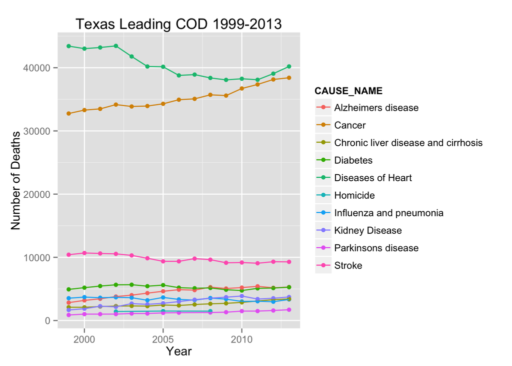

```r
source("../01 Data/Graph1.R", echo = TRUE)
```

#### Tableau

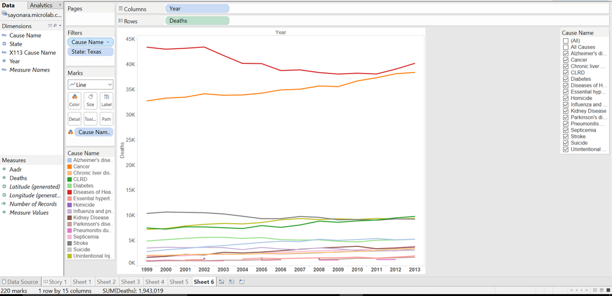

#### Shiny

https://herbertg14.shinyapps.io/FinalProject

### Visualization 2: Effects of Prescription Drug Spending per state and Suicide deaths

Despite the fact that most deaths were caused by cancer and cardiovascular diseases. We noticed that deaths by suicide was suprisingly high and we wanted to know any causes for that based on medical spending within the states. We felt as if prescription drug spending would be closely associated with the number of deaths by suicide. When joining these two data sets we can that there is a significantly strong positive correlation between spending on prescription drugs within the State and the number of suicides in the year 2009.

#### Rstudio

```
##
## > df1 <- COD %>% select(STATE, YEAR, AADR, CAUSE_NAME,
## +     DEATHS) %>% filter(YEAR == 2009 & CAUSE_NAME == "Suicide")
##
## > df2 <- NHCE %>% filter(CODE == 7, COUNTRY_GROUP ==
## +     "State") %>% select(ITEM, STATE_NAME, Y2009) %>% rename(STATE = STATE_NAME,
## +     SPENDIN .... [TRUNCATED]
##
## > df <- dplyr::inner_join(df1, df2, by = "STATE")
```

```
##
## > ggplot() + coord_cartesian() + scale_x_continuous() +
## +     scale_y_continuous() + labs(title = "Prescription Drug Spending vs. Deaths by Suicide") .... [TRUNCATED]
```

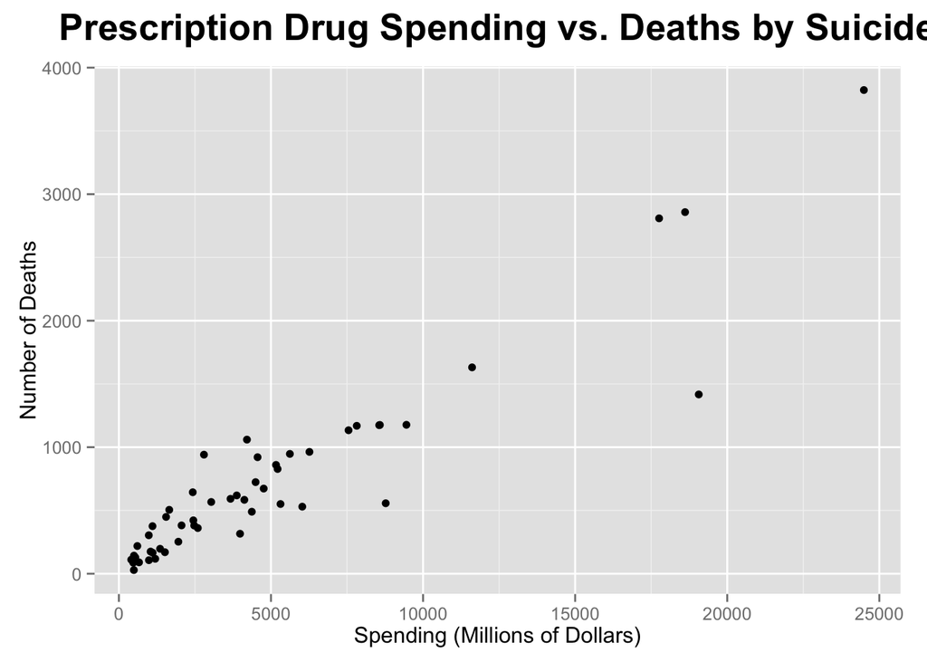

```r
source("../01 Data/Graph2.R", echo = TRUE)
```

#### Tableau

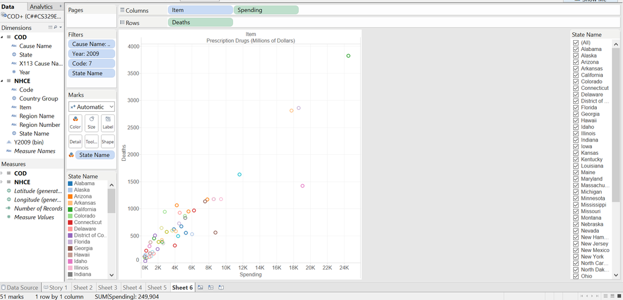

#### Shiny

https://herbertg14.shinyapps.io/FinalProject

## Visualization 3: Effects of Inflation

When we first started playing with the data, we were looking at the breakdown of healthcare spending by the different types of spending. After overlapping a few years of data were realized that we wanted to show a time series of healthcare expenditures. We broke it down by item using different colors to represent the respective proportions of different items within the total annual healthcare spending bar. After seeing how significant the rise was, we decided that we wanted to see how it compared to inflation. We wrote a lengthy SQL code to include inflation data and then realized that in addition to inflation we needed to consider population growth. By the end the time series showed annual per capita spending values.

It is interesting to note that the earlier graph showing the Texas Leading Causes of Death shows the total number of deaths remaining relatively steady despite significant population growth. This reflects the increasing life expectancy of people due to the improvements in healthcare, technology, diet, etc… Some of these improvements can be attributed to the increased per capita spending on development of new medications, technologies, and services.

#### Rstudio

```
##
## > INFLATION <- data.frame(fromJSON(getURL(URLencode("skipper.cs.utexas.edu:5001/rest/native/?query=\"select * from INFLATION\""),
## +     httpheader =  .... [TRUNCATED]
##
## > POPULATION = data.frame(fromJSON(getURL(URLencode("skipper.cs.utexas.edu:5001/rest/native/?query=\"select * from CENSUS_ESTIMATES\""),
## +     httphe .... [TRUNCATED]
##
## > NHCE <- melt(data.frame(fromJSON(getURL(URLencode("skipper.cs.utexas.edu:5001/rest/native/?query=\"\"\"\n                                            .... [TRUNCATED]
##
## > ggplot() + coord_cartesian() + scale_x_discrete() +
## +     scale_y_continuous() + labs(title = "Annual Per Capita Healthcare Expenditure in Texas by ..." ... [TRUNCATED]
```

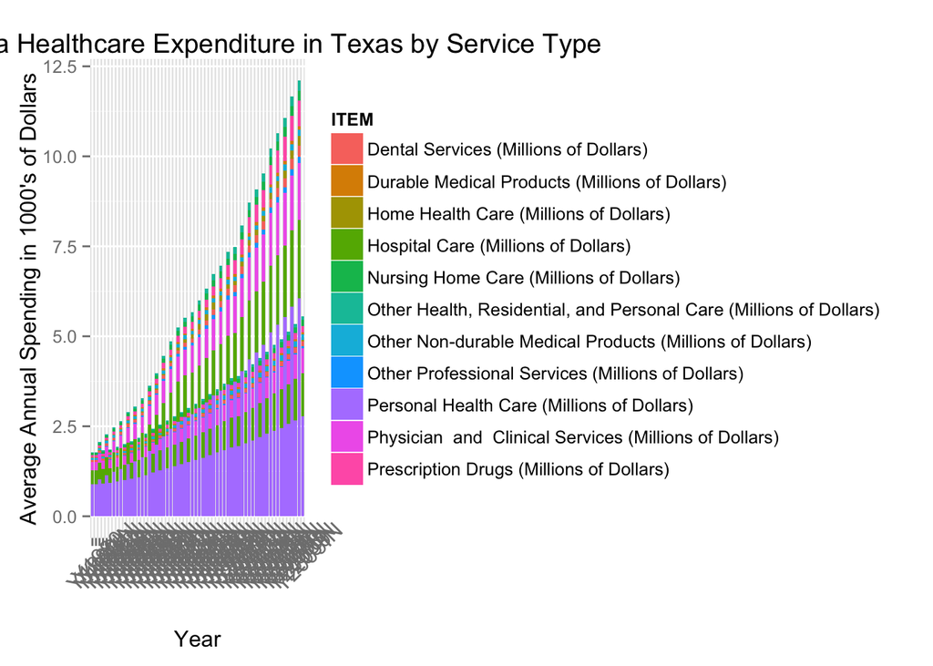

```r
source("../01 Data/Ryan_BarChart_SQL.R", echo = TRUE)
```

#### Tableau

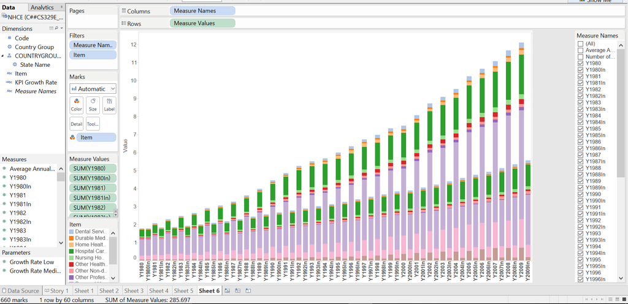

#### Shiny

https://herbertg14.shinyapps.io/FinalProject

### Visualization 4: Healthcare Expenditures by State

Thus far, we have looked at healthcare from a local and science-focused perspective and then a macro, economics-focused perspective. The final set of visualizations in this project will analyze healthcare expenditures per capita by region and item to give a better understanding of where the US healthcare system’s inefficiencies lie.

First, we created a Crosstab with a KPI to view the average growth in healthcare expenditures over the past 30 years by State and Item. The KPI classified growth less than 7% as ‘Low’ (colored green), between 7-10% as ‘Medium’ (colored blue), and greater than 10% as ‘High’ (colored red). It gives a quick glance at the fastest-growing expenditures, unadjusted for inflation, allowing us to compare their relative growth rates.

#### Rstudio

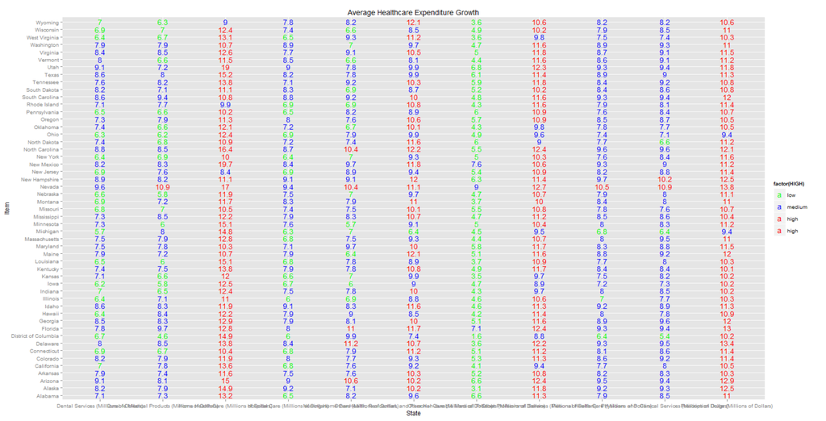

#### Tableau

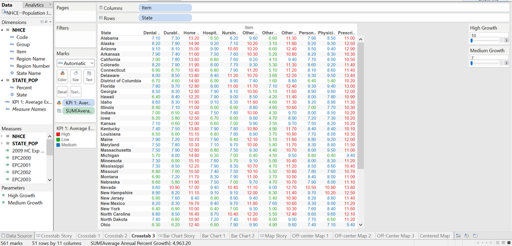

#### Shiny

https://herbertg14.shinyapps.io/FinalProject

The corresponding fourth tab in Shiny shows a web-hosted version of this crosstab with sliders for the KPi’s.

Second, we wanted to get a better regional understanding of healthcare expenditures per capita. Therefore, we created a bar chart ranking states by healthcare expenditures per capita in 2009, colored by region, and filtered by Item.

#### Rstudio

```
##
## > NHCE <- data.frame(fromJSON(getURL(URLencode("skipper.cs.utexas.edu:5001/rest/native/?query=\"select * from NHCE\""),
## +     httpheader = c(DB = "jd ..." ... [TRUNCATED]
##
## > state_pop <- data.frame(fromJSON(getURL(URLencode("skipper.cs.utexas.edu:5001/rest/native/?query=\"select * from state_pop\""),
## +     httpheader =  .... [TRUNCATED]
##
## > df1 <- NHCE %>% select(STATE_NAME, Y2009, REGION_NAME,
## +     CODE) %>% filter(STATE_NAME != "null", CODE != "12") %>%
## +     group_by(STATE_NAME, R .... [TRUNCATED]
##
## > df2 <- state_pop %>% select(STATE, NINE) %>% filter(STATE %in%
## +     c("Source: ", "Puerto Rico") == FALSE, NINE != "null")
##
## > df <- dplyr::inner_join(df1, df2, by = "STATE")
```

```
##
## > df <- df %>% select(STATE, REGION_NAME, Y2009, NINE) %>%
## +     mutate(HC_exp_capita = as.numeric(as.character(1e+06 * as.numeric(as.character(Y2009 .... [TRUNCATED]
##
## > ggplot(df, aes(x = reorder(STATE, HC_exp_capita),
## +     y = HC_exp_capita, fill = REGION_NAME)) + labs(title = "Healthcare Expenditures per Capita  ..." ... [TRUNCATED]
```

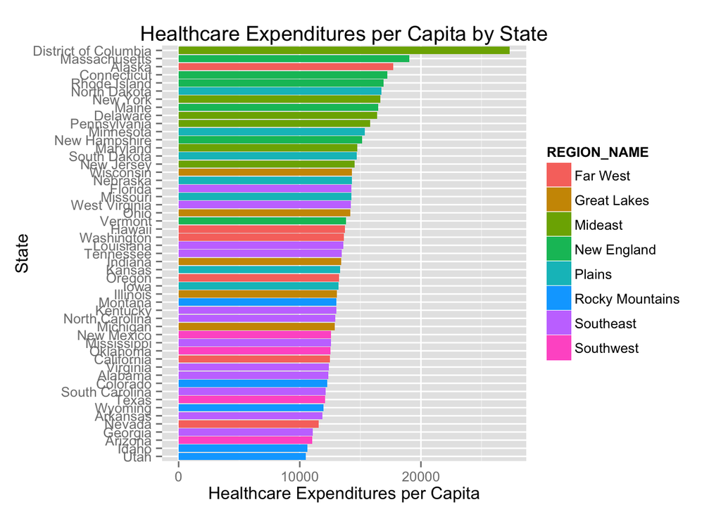

```r
source("../01 Data/Varun_Bar Chart - Exp per Capita.R", echo = TRUE)
```

#### Tableau

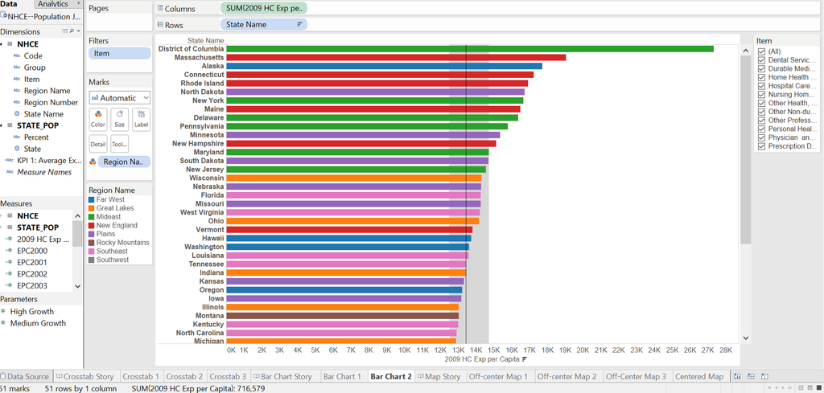

We chose not to host this chart in Shiny because it would be unnecessarily redundant.

The third and final visualization in this section was created exclusively in Tableau. We wanted to see the above results in map form to better see the regional clustering. A screen capture of the Tableau workbook is displayed below. Filtering by item and region allows for greater insight into specific areas.

#### Tableau

[figure not shown]